# Meyer_InClass_Midterm

# Question 7: Consider again the women’s tennis data set, wta_matches_2019.csv, where each row corresponds to a match played on the WTA (Women’s Tennis Association) tour. Important variables to consider for this problem include:

winner_name, the name of the player who won the match loser_name, the name of the player who lost the match

Construct a lollipop chart that shows the 10 WTA tennis players with the highest average number of aces in the 2019 season who have played at least 20 matches.

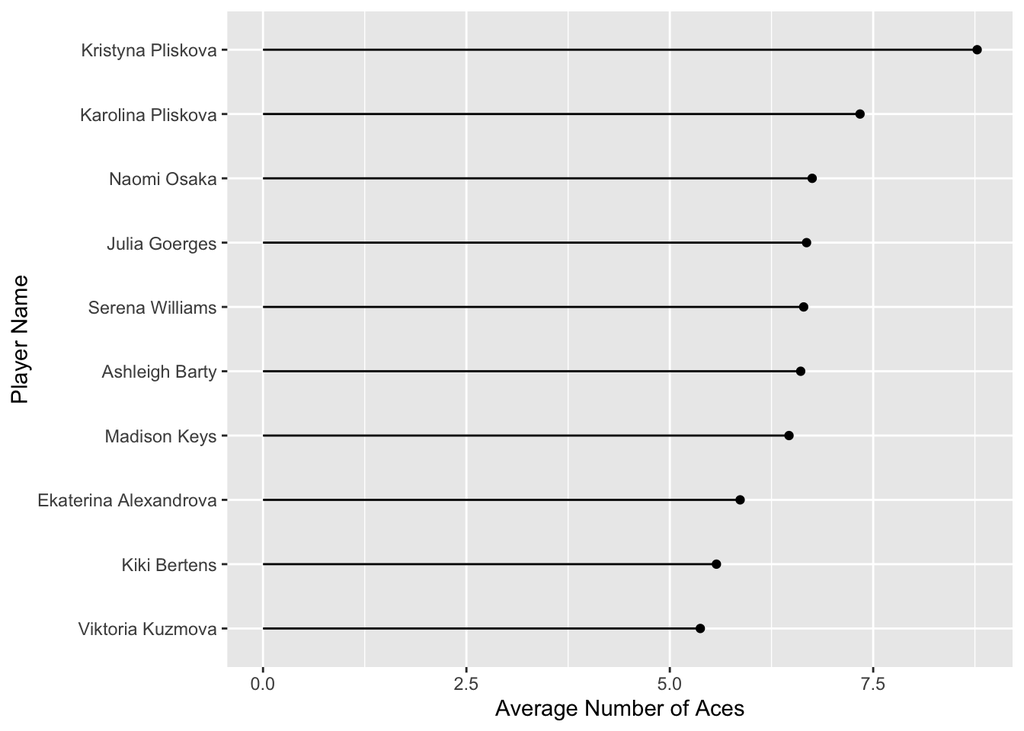

```r
library(tidyverse)
library(here)
wta_df <- read_csv(here("data/wta_matches_2019.csv"))
wta_long <- wta_df %>% pivot_longer(c(winner_name, loser_name),
                                    names_to = "won_or_lost",
                                    values_to = "player") %>%
  select(won_or_lost, player, everything())

wta_ace <- wta_long %>% select(won_or_lost, player, w_ace, l_ace) %>%
  mutate(aces = if_else(won_or_lost == "winner_name",
                        true = w_ace,
                        false = l_ace)) %>%
  filter(!is.na(w_ace))

wta_total <- wta_long %>% group_by(player) %>%
  summarise(totalmatches = n()) %>%
  filter(totalmatches >= 20)

wta_final <- semi_join(wta_ace, wta_total, by = c("player" = "player"))

wta_final <- wta_final %>% group_by(player) %>%
  summarise(meanaces = mean(aces)) %>%
  arrange(desc(meanaces)) %>%
  slice(1:10) %>%
  mutate(player = fct_reorder(player, meanaces))

ggplot(data = wta_final, aes(x = player, y = meanaces)) +
  geom_point() +
  geom_segment(aes(x = player, xend = player, y = 0, yend = meanaces)) +
  coord_flip() +
  labs(x = "Player Name",
       y = "Average Number of Aces")
```

# Question 8:

## part a. Consider the lollipop plot you made in Question 7. Why is this plot not the best plot to make to look at the top women’s servers in 2019? (There might be a couple of reasons but you should reference one that we have explicitly talked about in class a lot).

We should really create a plot that shows some variability, such as adding the mean onto a scatterplot for each of the players. It is good to show the average number of aces (top women’s servers), along with the variability in the number of aces they hit.

## part b. Fix the plot so that it no longer has the issue you described in Question 8a.

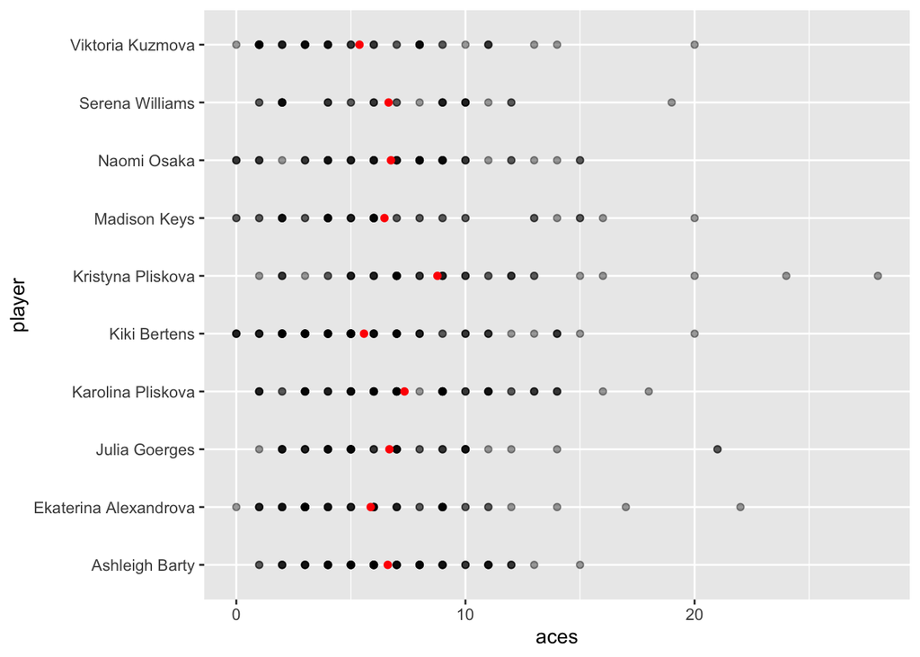

```r
library(tidyverse)
library(here)
wta_df <- read_csv(here("data/wta_matches_2019.csv"))
wta_long <- wta_df %>% pivot_longer(c(winner_name, loser_name),
                                    names_to = "won_or_lost",
                                    values_to = "player") %>%
  select(won_or_lost, player, everything())

wta_ace <- wta_long %>% select(won_or_lost, player, w_ace, l_ace) %>%
  mutate(aces = if_else(won_or_lost == "winner_name",
                        true = w_ace,
                        false = l_ace)) %>%
  filter(!is.na(w_ace))

wta_total <- wta_long %>% group_by(player) %>%
  summarise(totalmatches = n()) %>%
  filter(totalmatches >= 20)

wta_8 <- semi_join(wta_ace, wta_total, by = c("player" = "player"))

wta_8_final <- semi_join(wta_8, wta_final, by = c("player" = "player"))

ggplot(data = wta_8_final, aes(x = player, y = aces)) +
  geom_point(alpha = 0.4) +
  geom_point(data = wta_final, aes(y = meanaces),
             colour = "red") +
  coord_flip()
```